# FIRST Robotics Competition: How Much Better Are Experienced Teams?

Max Narvaez and Ryan Harvey

November 23, 2020

[figure not shown]

```r
library(tidyverse)
library(maps)

years <- 2002:2019

matches <- readRDS("matches.rds") %>%
  mutate(week = case_when(
    event_type == "district_championship_division" ~ "dcmpd",
    event_type == "district_championship" ~ "dcmp",
    event_type == "championship_division" ~ "cmpd",
    event_type == "championship_finals" ~ "cmpf",
    event_type == "festival_of_champions" ~ "foc",
    TRUE ~ as.character(week)
  )) %>%
  mutate(week = factor(week, c("0", "1", "2", "3", "4", "5", "6", "7",
                               "dcmpd", "dcmp", "cmpd", "cmpf", "foc")))

scores <- matches %>%
  pivot_longer(cols = c("red_score", "blue_score"),
               names_to = "alliance",
               values_to = "score") %>%
  mutate(alliance = as.factor(alliance))
scores$alliance <- recode_factor(scores$alliance,
                                 "red_score" = "red",
                                 "blue_score" = "blue")

matches_by_team <- scores %>%
  pivot_longer(cols = c("red_alliance_1", "red_alliance_2",
                        "red_alliance_3", "red_alliance_4",
                        "blue_alliance_1", "blue_alliance_2",
                        "blue_alliance_3", "blue_alliance_4"),
               names_to = "position",
               values_to = "team") %>%
  filter(!is.na(team)) %>%
  separate(position, sep = "_alliance_", into = c("team_alliance", "position")) %>%
  filter(alliance == team_alliance) %>%
  select(!team_alliance) %>%
  mutate(team_num = as.integer(str_remove(team, "frc")))

teams <- readRDS("teams.rds") %>%
  filter(rookie_year != 2020) %>%
  rowwise() %>%
  mutate(years_competed = length(years))

team_avg_by_year <- matches_by_team %>%
  group_by(team, team_num, year) %>%
  summarize(avg_score = mean(score))

team_percentile_by_year <- data.frame(
  team = character(),
  team_num = integer(),
  year = integer(),
  avg_score = double(),
  percentile = double()
)

for (yr in years) {
  x <- team_avg_by_year %>%
    filter(year == yr)
  x$percentile <- ecdf(x$avg_score)(x$avg_score) * 100

  team_percentile_by_year <- bind_rows(team_percentile_by_year, x) %>%
    arrange(team_num)
}

team_percentile_avg <- team_percentile_by_year %>%
  group_by(team, team_num) %>%
  summarize(avg_performance = mean(percentile)) %>%
  ungroup()
```

## Research Question

**Do FIRST Robotics Competition teams that have more experience perform better?**

To measure performance, we will use:

- A team’s average score’s percentile when compared to all other teams’ scores in that year (we’ll explain what this means later)

To measure experience within a season, we will use:

- The number of weeks of competition that have passed
- The number of events a team has attended in a season

To measure experience across seasons, we will use:

- The number of seasons a team has competed in
- The number of matches a team has played in

We will answer this question shortly, but first let’s get some background on what the FIRST Robotics Competition is.

## Background

The [FIRST Robotics Competition (FRC)](https://www.firstinspires.org/robotics/frc) is a competition where teams build a robot for 6ish weeks, then compete in one or more events to try to secure a spot in the championship.

### Competition Structure

An event consists of two parts, qualification and playoffs. During the qualification matches, you play matches with algorithmically assigned teams against another alliance. An alliance is a group of three teams that are working together to win against the other alliance. There is a blue alliance and a red alliance. During the playoff matches, the alliances are picked by the top 8 teams. During most events, you pick two other teams to be part of your alliance through the rest of the playoffs. If one of your robots breaks, you can request a backup robot to be added to your alliance to replace the broken robot. At the championship, you pick three other teams, which means your backup is built-in to your alliance, because you only ever compete with three robots.

A regional is a competition of ~50-60 teams. The winning alliance gets to go to the championship. If a team in the winning alliance has already qualified for the championship, then a team from the second-place alliance gets to go. A district is a geographical area where teams attend two ~30-40 team events instead, followed by a district championship. The top teams in the district championship get to go to the championship.

Ever since 2005, there have been two alliances of 3 teams each. In 1999-2000 and 2002-2004 there were 2 team alliances, 2001 was 4v0, and 1992-1998 did not have alliances. We only have match data from 2002 to the present.

Each year, teams are challenged by a new competition. Everything from making robots play basketball to attacking a castle have been themes for competitions. One year, teams may be asked to collect and launch balls into a target (2002, 2004, 2006, 2008, 2009, 2010, 2012, 2014, 2016, 2017, 2019) and the next year be asked to pick up inflatable shapes and place them onto pegs (2007, 2011). There have also been years with stacking bins (2003, 2015), a year with tetras (basically a hollow tetrahedron that can be stacked) (2005), a year of ultimate frisbee (2013), a year with large plastic gears (2017), and a year with milk crates (2018).

### Team Locations

The FIRST Robotics Competition (FRC) started in 1992 in a high school gym in Manchester, NH. In 1992, there were 28 teams at 1 competition. In 2019, there were over 3800 active teams competing at over 160 events worldwide.

Teams are located all over the world, with 31 countries represented in 2019.

```r
teams %>%
  filter(2019 %in% years) %>%
  group_by(country) %>%
  summarize(count = n()) %>%
  arrange(desc(count)) %>%
  knitr::kable(col.names = c("Country", "Number of Teams"),
               align = "ll")
```

| Country | Number of Teams |
| --- | --- |
| USA | 3121 |
| Canada | 270 |
| Turkey | 80 |
| Mexico | 76 |
| China | 67 |
| Israel | 66 |
| Australia | 45 |
| Chinese Taipei | 21 |
| Brazil | 14 |
| Dominican Republic | 4 |
| Netherlands | 4 |
| Chile | 3 |
| India | 3 |
| Japan | 3 |
| Switzerland | 3 |
| United Kingdom | 3 |
| Colombia | 2 |
| France | 2 |
| New Zealand | 2 |
| Poland | 2 |
| Afghanistan | 1 |
| Czech Republic | 1 |
| Germany | 1 |
| Indonesia | 1 |
| Libya | 1 |
| Norway | 1 |
| South Africa | 1 |
| Sweden | 1 |
| Ukraine | 1 |
| Venezuela | 1 |
| Vietnam | 1 |

The vast majority of the teams are located in the US. Every state has at least 1 team.

```r
teams %>%
  filter(2019 %in% years & country == "USA") %>%
  mutate(state_prov = case_when(
    state_prov == "CT" ~ "Connecticut",
    state_prov == "MI" ~ "Michigan",
    state_prov == "TX" ~ "Texas",
    TRUE ~ state_prov
  )) %>%
  group_by(state_prov) %>%
  summarize(count = n()) %>%
  arrange(desc(count)) %>%
  knitr::kable(col.names = c("State/Province", "Number of Teams"),
               align = "ll")
```

| State/Province | Number of Teams |
| --- | --- |
| Michigan | 540 |
| California | 310 |
| Minnesota | 221 |
| Texas | 176 |
| New York | 174 |
| Washington | 98 |
| Florida | 89 |
| Georgia | 85 |
| New Jersey | 83 |
| Virginia | 75 |
| Missouri | 74 |
| Massachusetts | 73 |
| North Carolina | 70 |
| Pennsylvania | 68 |
| Ohio | 65 |
| Illinois | 63 |
| Wisconsin | 59 |
| Indiana | 57 |
| Arizona | 56 |
| Connecticut | 55 |
| Oregon | 52 |
| Oklahoma | 47 |
| New Hampshire | 45 |
| South Carolina | 42 |
| Maryland | 41 |
| Colorado | 40 |
| Arkansas | 39 |
| Louisiana | 39 |
| Tennessee | 33 |
| Hawaii | 28 |
| Iowa | 26 |
| Utah | 25 |
| Kansas | 23 |
| Nevada | 22 |
| Maine | 21 |
| Idaho | 15 |
| Alabama | 14 |
| Kentucky | 13 |
| Mississippi | 12 |
| District of Columbia | 10 |
| New Mexico | 10 |
| North Dakota | 5 |
| Rhode Island | 5 |
| Vermont | 5 |
| West Virginia | 4 |
| Wyoming | 4 |
| Nebraska | 3 |
| Delaware | 2 |
| Montana | 2 |
| Alaska | 1 |
| Puerto Rico | 1 |
| South Dakota | 1 |

This is the distribution of US teams (note that 28 Hawaiian teams, 1 Alaskan team and 1 Puerto Rican team are omitted)

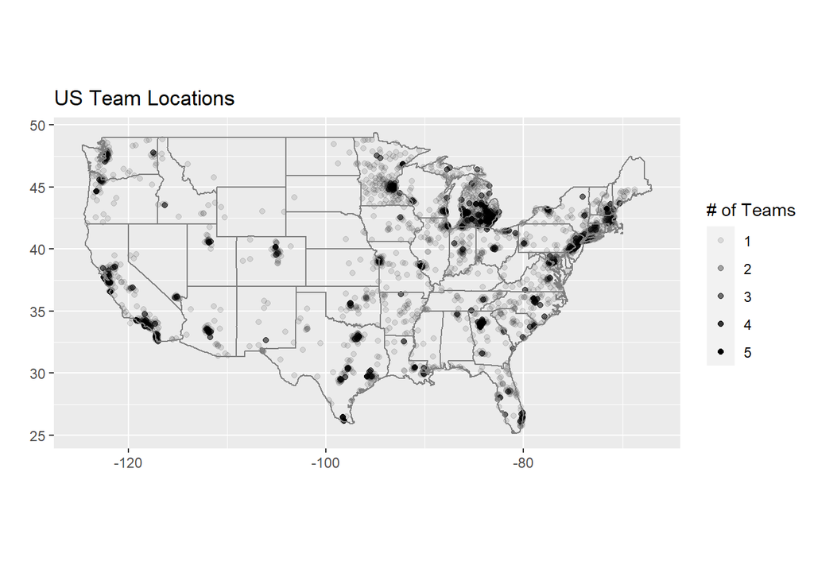

```r
zip.codes <- read.csv("zipcode.csv")
teams %>%
  filter(2019 %in% years & country == "USA") %>%
  mutate(postal_code = parse_number(postal_code)) %>%
  left_join(zip.codes, by = c("postal_code" = "ZIP")) %>%
  filter(!is.na(LAT) & !is.na(LNG)) %>%
  filter(LNG > -140 & LAT > 20) %>%
  group_by(postal_code) %>%
  summarize(count = n(), LAT = LAT, LNG = LNG) %>%
  ggplot(aes(LNG, LAT, alpha = count)) +
  geom_point() +
  borders("state") +
  coord_quickmap() +
  labs(title = "US Team Locations",
       x = "",
       y = "",
       alpha = "# of Teams")
```

## Calculating Performance

Because the competition changes every year, comparing raw scores from one year to the next is not a good measure of performance. For example, the 2010 competition had an average match score of 4.08, while the 2018 competition had an average match score of 291.90.

```r
scores %>%
  group_by(year) %>%
  summarize(avg_score = mean(score)) %>%
  knitr::kable(col.names = c("Year", "Average Score"),
               align = "ll")
```

| Year | Average Score |
| --- | --- |
| 2002 | 29.921029 |
| 2003 | 48.985660 |
| 2004 | 59.851016 |
| 2005 | 28.246132 |
| 2006 | 35.213372 |
| 2007 | 30.064372 |
| 2008 | 42.879916 |
| 2009 | 56.692035 |
| 2010 | 4.079307 |
| 2011 | 38.120657 |
| 2012 | 25.047814 |
| 2013 | 64.813903 |
| 2014 | 100.211908 |
| 2015 | 75.583587 |
| 2016 | 85.289039 |
| 2017 | 233.390947 |
| 2018 | 291.902244 |
| 2019 | 54.930552 |

We found that a good way to compare across years is to compute a team’s performance relative to the rest of the teams in the competition that year. By calculating the average score achieved by each team, we can determine what percentile each team achieved in a given year.

For example, the performance of Team 2855 (Max’s former team) is shown below:

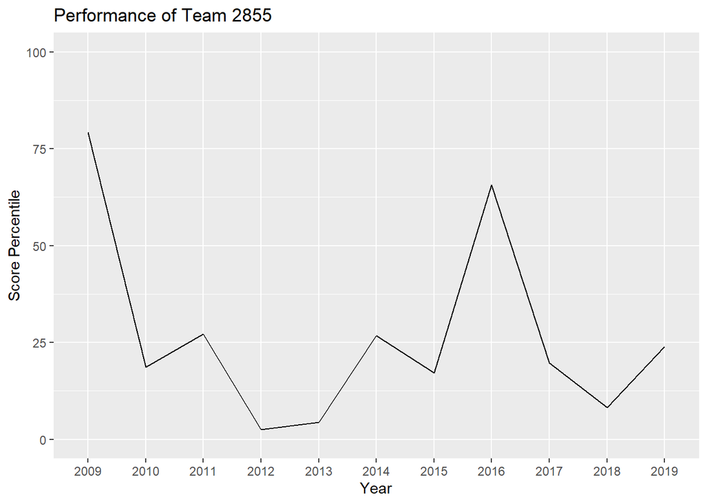

```r
team_percentile_by_year %>%
  filter(team_num == 2855) %>%
  ggplot(aes(as.factor(year), percentile, group = 1)) +
  geom_line() +
  ylim(0, 100) +
  labs(title = "Performance of Team 2855",
       x = "Year",
       y = "Score Percentile")
```

As shown here, Team 2855 has had a couple of good years, but overall has been an ok team at best.

We can compare this to Team 3691, based out of Northfield High School:

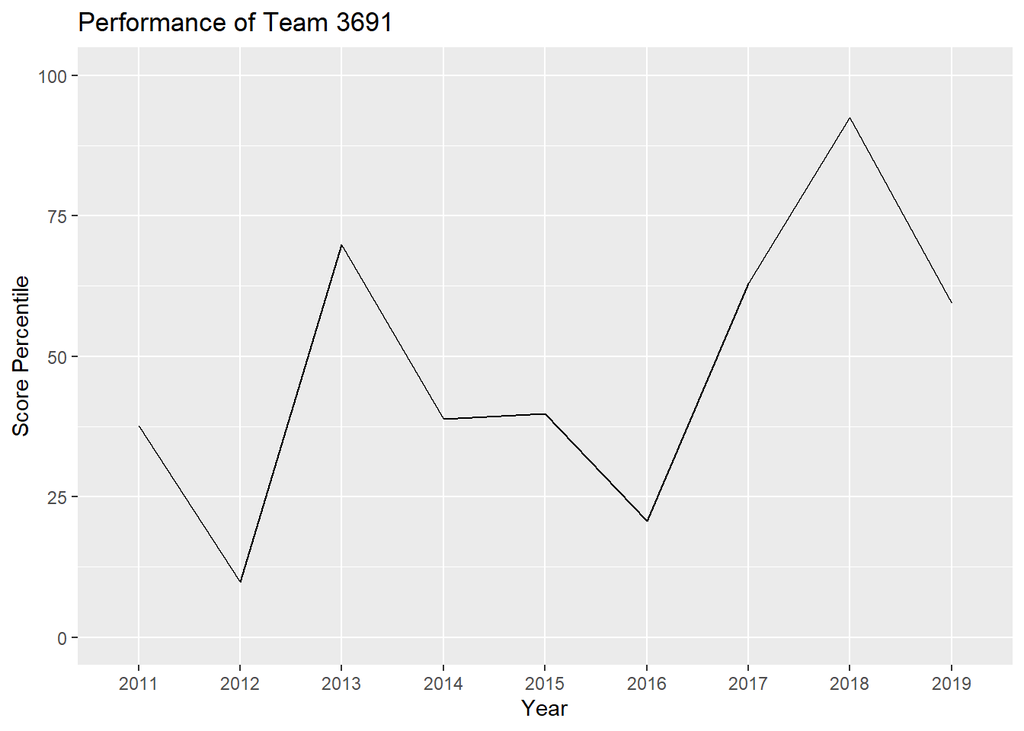

```r
team_percentile_by_year %>%
  filter(team_num == 3691) %>%
  ggplot(aes(as.factor(year), percentile, group = 1)) +
  geom_line() +
  ylim(0, 100) +
  labs(title = "Performance of Team 3691",
       x = "Year",
       y = "Score Percentile")
```

At first glance, it seems like Team 3691 has been a better-performing team than Team 2855. We can average all of a team’s score percentiles to determine an average score percentile.

```r
team_percentile_avg %>%
  filter(team_num %in% c(2855, 3691)) %>%
  left_join(teams, by = c("team_num" = "team_number")) %>%
  arrange(team_num) %>%
  select(team_num, nickname, rookie_year, years_competed, avg_performance) %>%
  head(20) %>%
  knitr::kable(col.names = c("Team #", "Nickname", "Rookie Year",
                             "Years Competed", "Average Score Percentile"),
               align = "lllll")
```

| Team # | Nickname | Rookie Year | Years Competed | Average Score Percentile |
| --- | --- | --- | --- | --- |
| 2855 | BEASTBOT | 2009 | 11 | 26.67849 |
| 3691 | RoboRaiders | 2011 | 10 | 47.94250 |

This confirms that Team 3691 is a better-performing team than Team 2855.

This metric is not perfect, however, because it does not account for factors such as who your alliance members are and who is on the opposing alliance. For example, in one match you could have one of the top teams in the competition on your alliance which helps you easily win. In another match, both of your alliance members’ robots could break which makes you lose.

## Performance Within a Season

### Performance by Week of Competition

To evaluate performance within a season, we can compare each week of competition. Because the season is multiple weeks long, events happening on the same weekend are classified as being part of that “week” of competition.

In some years, performance does seem to improve, but in others it does not. For example, in 2017 the performance increased slightly as the weeks of the season progressed:

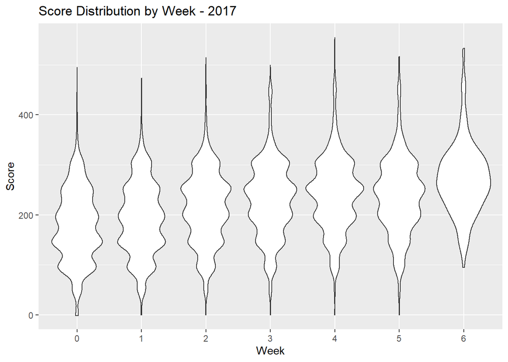

```r
scores %>%
  filter(year == 2017 & week %in% 0:6) %>%
  ggplot() +
  geom_violin(aes(week, score)) +
  labs(title = "Score Distribution by Week - 2017",
       x = "Week",
       y = "Score")
```

But in the 2009 season, there isn’t any obvious improvement:

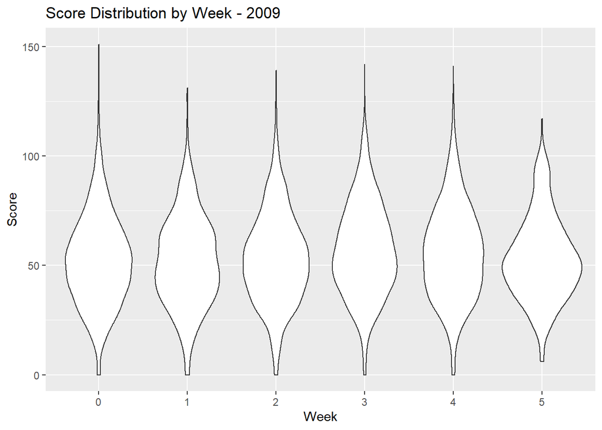

```r
scores %>%
  filter(year == 2009 & week %in% 0:5) %>%
  ggplot() +
  geom_violin(aes(week, score)) +
  labs(title = "Score Distribution by Week - 2009",
       x = "Week",
       y = "Score")
```

If we include the championship events, we consistently see an improvement over the weeks prior. Using 2009 again, we see that District Championships (`dcmp`), Championship Divisions (`cmpd`) and Championship Finals (`cmpf`) have a very noticeable improvement in scores.

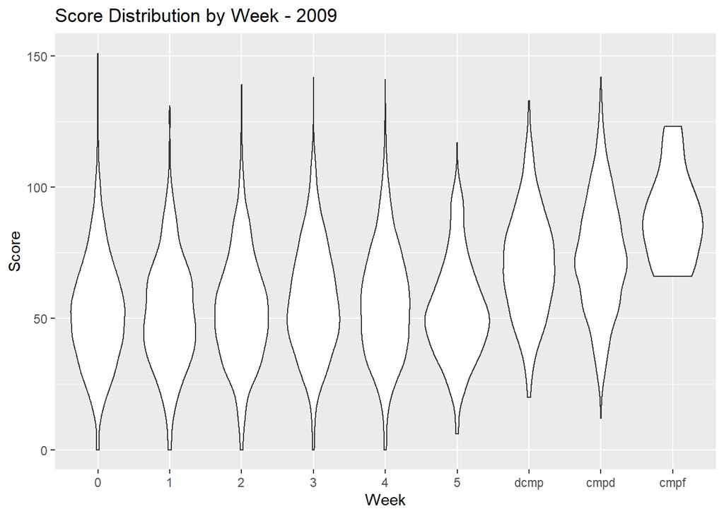

```r
scores %>%
  filter(year == 2009) %>%
  ggplot() +
  geom_violin(aes(week, score)) +
  labs(title = "Score Distribution by Week - 2009",
       x = "Week",
       y = "Score")
```

In many years, the difference between the Championship Finals and other levels can be drastic. Take the 2016 season as an example. The weeks progressed with minor improvements, the District Championships and Championship Divisions have an improvement in scores, but the Championship Finals have scores much higher.

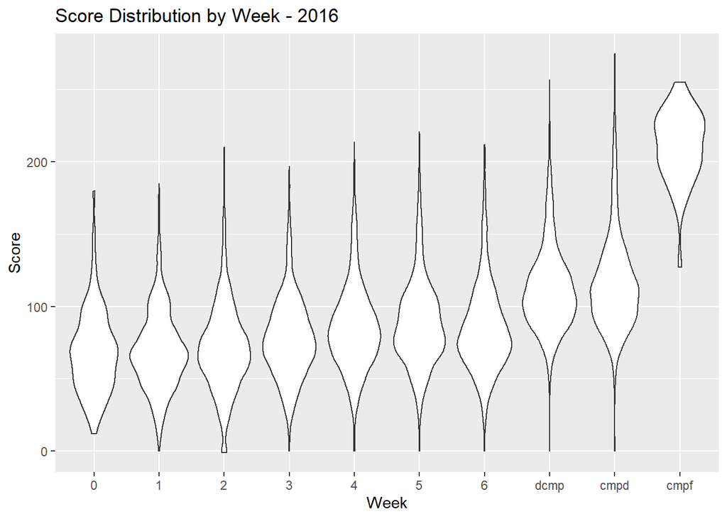

```r
scores %>%
  filter(year == 2016) %>%
  ggplot() +
  geom_violin(aes(week, score)) +
  labs(title = "Score Distribution by Week - 2016",
       x = "Week",
       y = "Score")
```

Using a boxplot, we can see that the average score in a Championship Finals match is almost double that of the average score in the Championship Divisions.

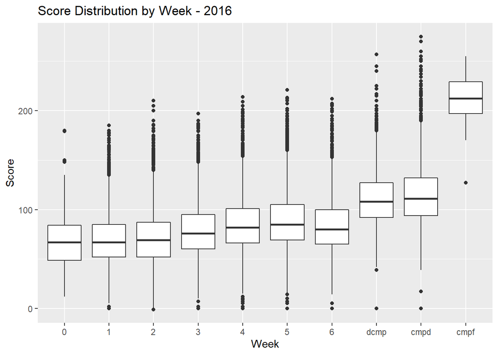

```r
scores %>%
  filter(year == 2016) %>%
  ggplot() +
  geom_boxplot(aes(week, score)) +
  labs(title = "Score Distribution by Week - 2016",
       x = "Week",
       y = "Score")
```

### Events Attended in a Season vs Performance

Our question here is to figure out how attending multiple events can impact your team’s performance and development. First, we will divide teams based on how many events they attended in a given season and see how the score percentile compares between number of events teams attended.

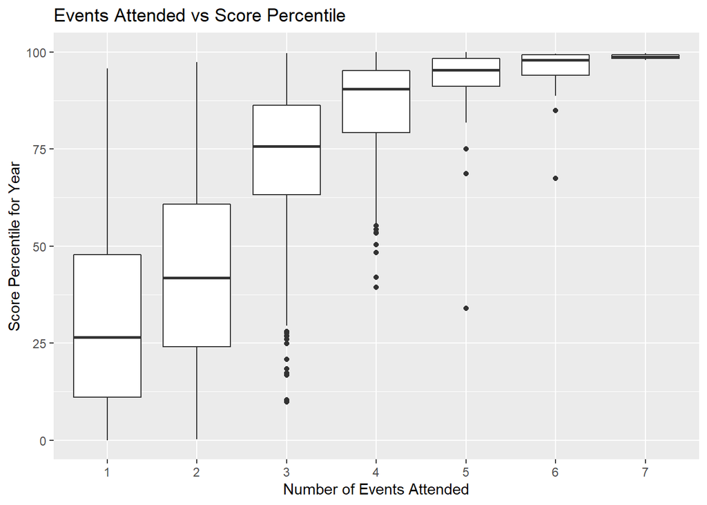

```r
team_events_per_year <- matches_by_team %>%
  group_by(team, team_num, year, event_key, event_type) %>%
  summarize() %>%
  ungroup() %>%
  group_by(team, team_num, year) %>%
  summarize(events = n(),
            non_cmp_events = length(event_key[event_type %in% c("regional",
                                                                "district")]),
            attended_dcmp = "district_championship" %in% event_type |
              "district_championship_division" %in% event_type,
            attended_cmp = "championship_division" %in% event_type,
            in_district = "district" %in% event_type)

team_events_per_year %>%
  left_join(team_percentile_by_year, by = c("team", "team_num", "year")) %>%
  filter(year == 2019) %>%
  ggplot() +
  geom_boxplot(aes(x = as.factor(events), y = percentile)) +
  labs(title = "Events Attended vs Score Percentile",
       x = "Number of Events Attended",
       y = "Score Percentile for Year")
```

These results aren’t too shocking, but they give us some useful information to keep in mind later. Clearly, the average score percentile for a team that attends a lot of events will be higher than a team that attends few since higher scoring teams are able to compete in more events.

It is interesting to see how high a team’s score percentile needs to be in order for them to expect to compete in many events. For example, in 2019 there were only a few teams that were below the 80th percentile that competed in 5 events.

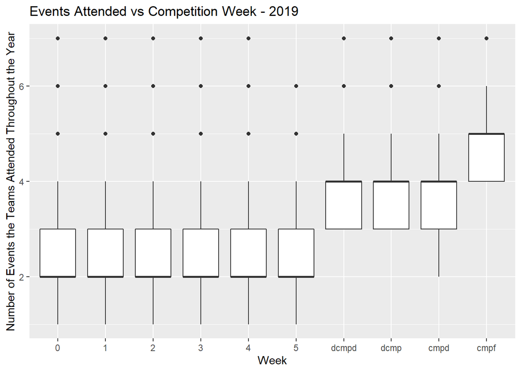

```r
team_events_per_year %>%
  filter(year == 2019) %>%
  inner_join(matches_by_team, by = c("team", "team_num", "year")) %>%
  group_by(team, year, events, week) %>%
  summarize(matches = n()) %>%
  ggplot() +
  geom_boxplot(aes(x = week, y = events)) +
  labs(title = "Events Attended vs Competition Week - 2019",
       x = "Week",
       y = "Number of Events the Teams Attended Throughout the Year")
```

These boxplots don’t reveal too many interesting trends, but they give us an understanding of how the average number of events a team participates is based on how far they make it in a season. When we investigate the 2019 scores of the championship division and the championship finals, we can use the median number of events attended 4 and 5, respectively to compare the team scores between teams that attended a lot of events and few events.

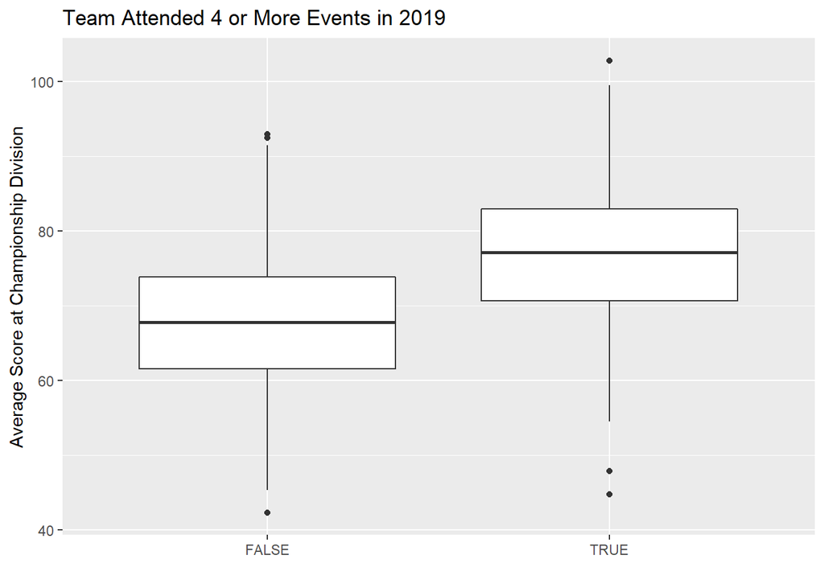

```r
team_avg_by_week_2019 <- team_events_per_year %>%
  filter(year == 2019) %>%
  inner_join(matches_by_team, by = c("team", "team_num", "year")) %>%
  group_by(team, year, events, week) %>%
  summarize(avg.score = mean(score))

week_avg_score_2019 <- team_avg_by_week_2019 %>%
  group_by(year, week) %>%
  summarise(avg.score = mean(avg.score))

team_avg_by_week_2019 %>%
  filter(week == "cmpd") %>%
  ggplot() +
  geom_boxplot(aes(x = (events >= 4), y = avg.score)) +
  labs(title = "Team Attended 4 or More Events in 2019",
       x = "",
       y = "Average Score at Championship Division")
```

This is the breakdown of teams in the championship division based on the 4 events attended cutoff we found previously. This plot is showing that the teams that attended 4 or more events in 2019 score better in this event than those who didn’t. We can’t use this as evidence that a team that has more experience will score better though since a winning team in a championship division will attend the championship finals, which adds to their event count. A more interesting plot is this same boxplot for the championship finals below.

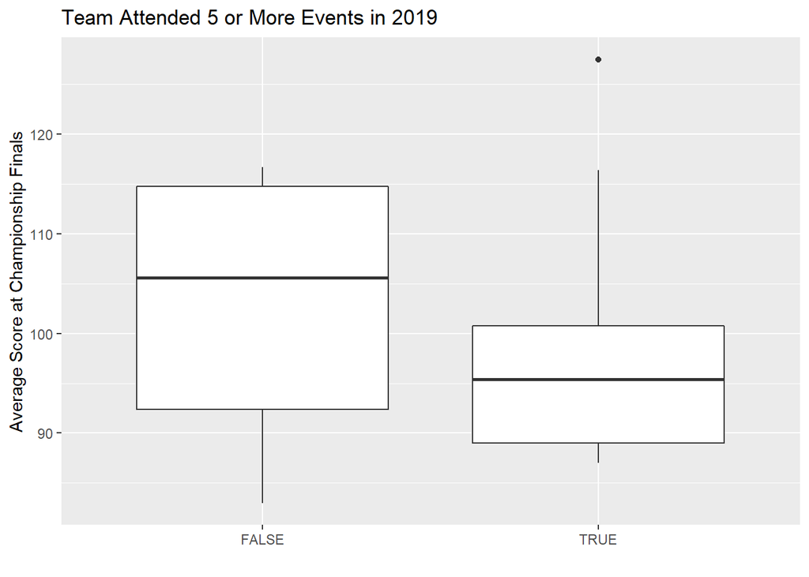

```r
team_avg_by_week_2019 %>%
  filter(week == "cmpf") %>%
  ggplot() +
  geom_boxplot(aes(x = (events >= 5), y = avg.score)) +
  labs(title = "Team Attended 5 or More Events in 2019",
       x = "",
       y = "Average Score at Championship Finals")
```

This plot tells the opposite story from before. The teams that made it to the finals who competed in more events actually performed worse in this case. This shows experience in a single season isn’t the most reliable indicator of season performance.

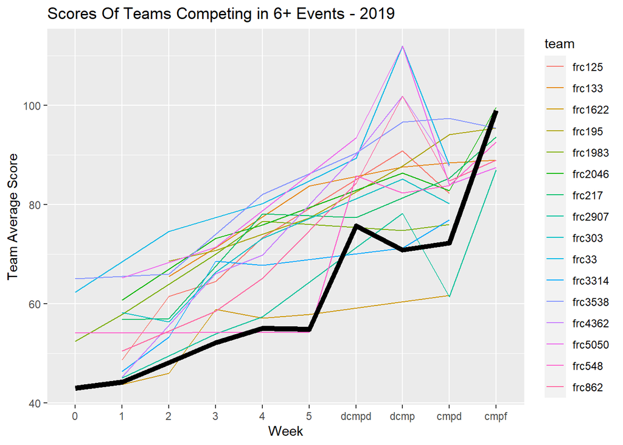

```r
team_avg_by_week_2019 %>%
  filter(events >= 6) %>%
  ggplot() +
  geom_line(aes(x = week, y = avg.score, group = team, color = team)) +
  geom_line(data = week_avg_score_2019, mapping = aes(x = week, y = avg.score, group = year), size = 2) +
  labs(title = "Scores Of Teams Competing in 6+ Events - 2019",
       x = "Week",
       y = "Team Average Score")
```

Here is a breakdown of score progression throughout the 2019 season for teams that competed in 6 or more events. These are the teams that competed in the most events of all the teams. All of the teams have positive trends that indicate the teams are still progressing through each of the many events they attend in the 2019 season.

The black line is the team average score each week for all the teams, not just those who attended a lot of events. The scores of the more experienced teams are usually higher than this average for each week. The black line has a few sudden jumps, which can be explained by the jump from regular season to postseason, and the jump to the finals. The jumps are caused by the competition level increases that eliminate lower scoring teams.

## Performance Across Multiple Seasons

### Top Performing Teams of All Time

We can use our average score percentile performance metric to determine the top teams of all time:

```r
team_percentile_avg %>%
  left_join(teams, by = c("team_num" = "team_number")) %>%
  arrange(desc(avg_performance)) %>%
  select(team_num, nickname, rookie_year, years_competed, state_prov, avg_performance) %>%
  head(20) %>%
  knitr::kable(col.names = c("Team #", "Nickname", "Rookie Year",
                             "Years Competed", "State/Province", "Average Score Percentile"),
               align = "llllll")
```

| Team # | Nickname | Rookie Year | Years Competed | State/Province | Average Score Percentile |
| --- | --- | --- | --- | --- | --- |
| 2056 | OP Robotics | 2007 | 14 | Ontario | 99.90801 |
| 2970 | eSchool eBots | 2009 | 1 | WI | 98.86567 |
| 5406 | Celt-X | 2015 | 6 | Ontario | 98.64966 |
| 2098 | Bulldogs | 2007 | 1 | GA | 98.45560 |
| 7457 | suPURDUEper Robotics | 2019 | 2 | Indiana | 97.89894 |
| 254 | The Cheesy Poofs | 1999 | 22 | California | 97.10775 |
| 1114 | Simbotics | 2003 | 18 | Ontario | 96.99516 |
| 3683 | Team DAVE | 2011 | 10 | Ontario | 96.98346 |
| 67 | The HOT Team | 1997 | 24 | Michigan | 96.91468 |
| 4414 | HighTide | 2012 | 2 | California | 96.80851 |
| 2753 | Team Overdrive | 2009 | 2 | NJ | 96.71322 |
| 7553 | OSTC - SWEET BOTS | 2019 | 2 | Michigan | 96.67553 |
| 5184 | TITANICS | 2014 | 1 | Alberta | 96.55172 |
| 4678 | CyberCavs | 2013 | 8 | Ontario | 96.19824 |
| 782 | Kilowatts | 2002 | 3 | CT | 96.15072 |
| 5172 | Gators | 2014 | 7 | Minnesota | 95.95098 |
| 71 | Team Hammond | 1996 | 25 | Indiana | 95.85849 |
| 7021 | TC Robotics | 2018 | 3 | Wisconsin | 95.73704 |
| 4917 | Sir Lancerbot | 2014 | 7 | Ontario | 95.12320 |
| 27 | Team RUSH | 1997 | 24 | Michigan | 95.11682 |

A team that stands out here is Team 2056 (aptly named “OP Robotics”), who has been able to perform at an impressive level in all 14 years they’ve competed, performing at the 99.91th score percentile on average. (Notice that the graph only shows the 95th to 100th percentiles, and yet they’re still at the top.)

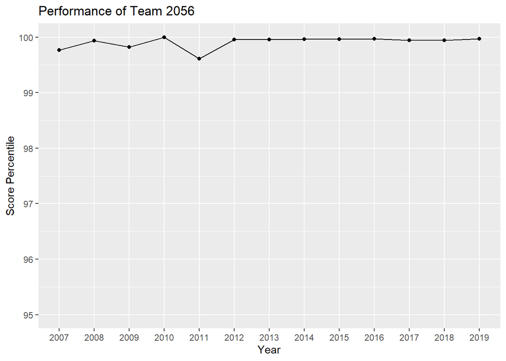

```r
team_percentile_by_year %>%
  filter(team_num == 2056) %>%
  ggplot(aes(as.factor(year), percentile, group = 1)) +
  geom_point() +
  geom_line() +
  ylim(95, 100) +
  labs(title = "Performance of Team 2056",
       x = "Year",
       y = "Score Percentile")
```

Other teams that stand out are teams 2970 and 2098, which only competed for one season but were one of the best teams in that season.

### Performance of Longest Competing Teams

We can also use our performance metric to compute the performance of some of the oldest teams. We have two possible ways to determine a team’s “age”:

- The number of seasons they have competed in
- The number of matches they have competed in

#### Number of Seasons Competed vs Average Performance

With the FIRST Robotics Competition starting back in 1992, there have been 29 seasons (including 2020). Only three teams exist that have competed in all of those seasons, though nine teams from 1992 are still active in 2020 (the other six took a year or more off at some point).

```r
teams %>%
  filter(rookie_year == 1992 & 2020 %in% years) %>%
  arrange(team_number) %>%
  select(team_number, nickname, state_prov, rookie_year, years_competed) %>%
  knitr::kable(col.names = c("Team #", "Nickname", "State/Province",
                             "Rookie Year", "Seasons Competed"),
               align = "lllll")
```

| Team # | Nickname | State/Province | Rookie Year | Seasons Competed |
| --- | --- | --- | --- | --- |
| 20 | The Rocketeers | New York | 1992 | 24 |
| 45 | TechnoKats Robotics Team | Indiana | 1992 | 29 |
| 126 | Gael Force | Massachusetts | 1992 | 29 |
| 131 | C.H.A.O.S. | New Hampshire | 1992 | 27 |
| 148 | Robowranglers | Texas | 1992 | 28 |
| 151 | Tough Techs | New Hampshire | 1992 | 27 |
| 157 | AZTECHS | Massachusetts | 1992 | 27 |
| 190 | Gompei and the H.E.R.D. | Massachusetts | 1992 | 27 |
| 191 | X-CATS | New York | 1992 | 29 |

These teams have been around a long time, but that isn’t the norm. That is a sample of only 9 out of about 8000 teams that have competed over the 29 seasons. The average number of seasons competed in is around 6 years, with a median of 4.

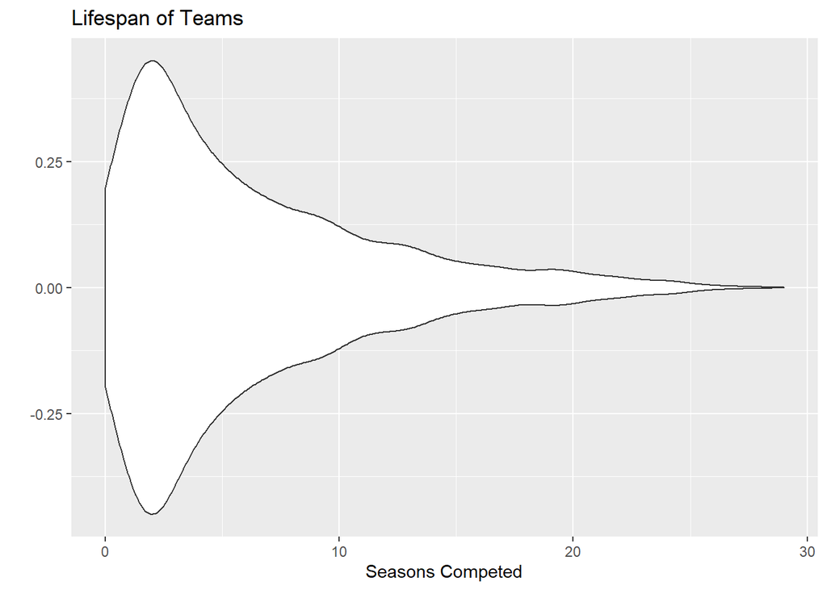

```r
teams %>%
  ggplot() +
  geom_violin(aes(years_competed, 0)) +
  labs(title = "Lifespan of Teams",
       x = "Seasons Competed",
       y = "")
```

Using the number of seasons competed, we can take the top 31 teams based on seasons competed (31 because that is the cutoff between 24 and 25 seasons competed).

```r
team_percentile_avg %>%
  left_join(teams, by = c("team_num" = "team_number")) %>%
  arrange(desc(years_competed), team_num) %>%
  select(team_num, nickname, state_prov, rookie_year, years_competed, avg_performance) %>%
  head(31) %>%
  mutate(nickname = ifelse(team_num == 173, "RAGE Robotics", nickname)) %>%
  knitr::kable(col.names = c("Team #", "Nickname", "State/Province",
                             "Rookie Year", "Seasons Competed",
                             "Average Score Percentile"),
               align = "llllll")
```

| Team # | Nickname | State/Province | Rookie Year | Seasons Competed | Average Score Percentile |
| --- | --- | --- | --- | --- | --- |
| 45 | TechnoKats Robotics Team | Indiana | 1992 | 29 | 82.05897 |
| 126 | Gael Force | Massachusetts | 1992 | 29 | 90.95443 |
| 191 | X-CATS | New York | 1992 | 29 | 84.97691 |
| 148 | Robowranglers | Texas | 1992 | 28 | 89.25748 |
| 81 | MetalHeads | Illinois | 1994 | 27 | 39.20181 |
| 131 | C.H.A.O.S. | New Hampshire | 1992 | 27 | 67.16112 |
| 151 | Tough Techs | New Hampshire | 1992 | 27 | 54.35748 |
| 155 | The Technonuts | Connecticut | 1994 | 27 | 66.55131 |
| 157 | AZTECHS | Massachusetts | 1992 | 27 | 64.12055 |
| 190 | Gompei and the H.E.R.D. | Massachusetts | 1992 | 27 | 78.16108 |
| 74 | Team CHAOS | Michigan | 1995 | 26 | 80.50757 |
| 108 | SigmaC@T Robotics Team | Florida | 1995 | 26 | 68.52366 |
| 111 | WildStang | Illinois | 1996 | 26 | 93.69707 |
| 141 | WOBOT | Michigan | 1995 | 26 | 80.07415 |
| 166 | Chop Shop | New Hampshire | 1995 | 26 | 69.57478 |
| 173 | RAGE Robotics | Connecticut | 1995 | 26 | 80.15928 |
| 177 | Bobcat Robotics | Connecticut | 1995 | 26 | 87.18504 |
| 8 | Paly Robotics | California | 1996 | 25 | 56.74377 |
| 28 | Pierson Whalers | New York | 1996 | 25 | 66.48026 |
| 33 | Killer Bees | Michigan | 1996 | 25 | 93.39666 |
| 58 | The Riot Crew | Maine | 1996 | 25 | 85.25065 |
| 69 | HYPER | Massachusetts | 1998 | 25 | 82.95772 |
| 71 | Team Hammond | Indiana | 1996 | 25 | 95.85849 |
| 85 | B.O.B. (Built on Brains) | Michigan | 1996 | 25 | 85.06791 |
| 88 | TJ² | Massachusetts | 1996 | 25 | 77.73869 |
| 116 | Epsilon Delta | Virginia | 1996 | 25 | 58.06107 |
| 120 | Cleveland’s Team | Ohio | 1995 | 25 | 61.69404 |
| 121 | Rhode Warriors | Rhode Island | 1996 | 25 | 76.64927 |
| 171 | Cheese Curd Herd | Wisconsin | 1995 | 25 | 71.05626 |
| 175 | Buzz Robotics | Connecticut | 1996 | 25 | 92.02480 |
| 176 | Aces High | Connecticut | 1996 | 25 | 84.64481 |

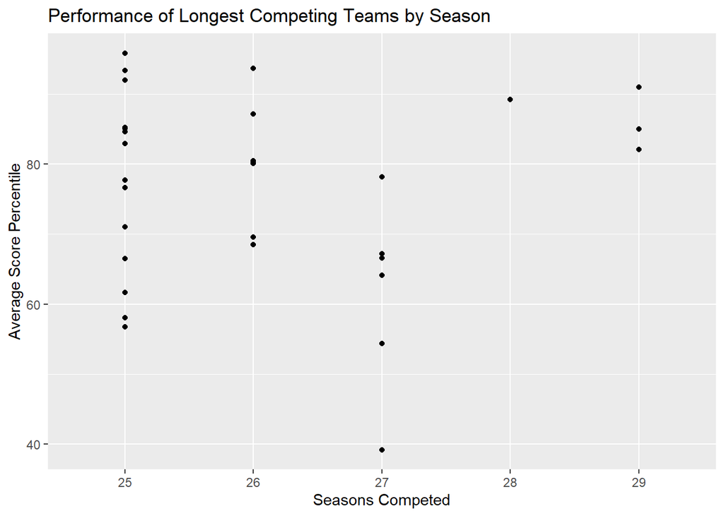

```r
team_percentile_avg %>%
  left_join(teams, by = c("team_num" = "team_number")) %>%
  filter(years_competed >= 25) %>%
  ggplot() +
  geom_point(aes(as.factor(years_competed), avg_performance)) +
  labs(title = "Performance of Longest Competing Teams by Season",
       x = "Seasons Competed",
       y = "Average Score Percentile")
```

This graph tells us that more seasons competed doesn’t always equate to higher performance. But, if we zoom out a bit and include all teams, we see that there actually is a distinct improvement over time.

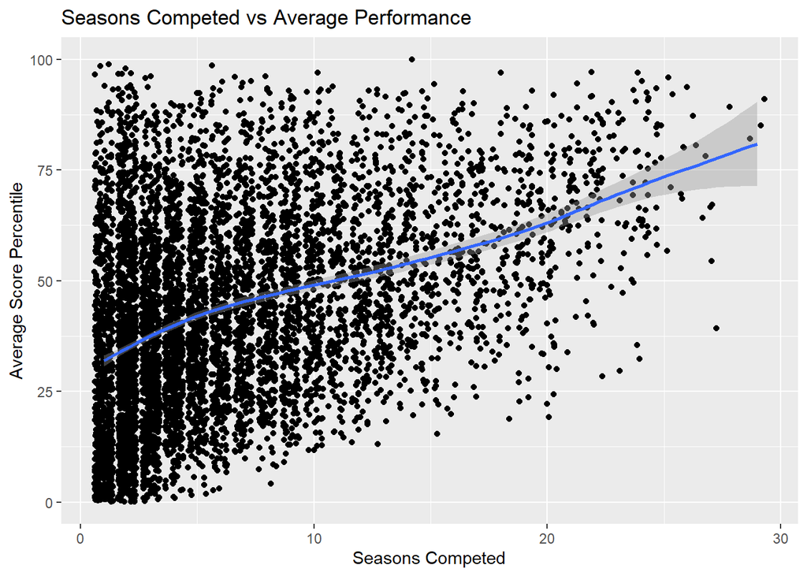

```r
team_percentile_avg %>%
  left_join(teams, by = c("team_num" = "team_number")) %>%
  ggplot(aes(years_competed, avg_performance)) +
  geom_jitter(height = 0) +
  geom_smooth() +
  ylim(0, 100) +
  labs(title = "Seasons Competed vs Average Performance",
       x = "Seasons Competed",
       y = "Average Score Percentile")
```

Averaging all of the data points for each number of seasons competed gives us the graph below. The improvement isn’t uniform and doesn’t always improve, especially above 15 seasons competed when the sample size is very small.

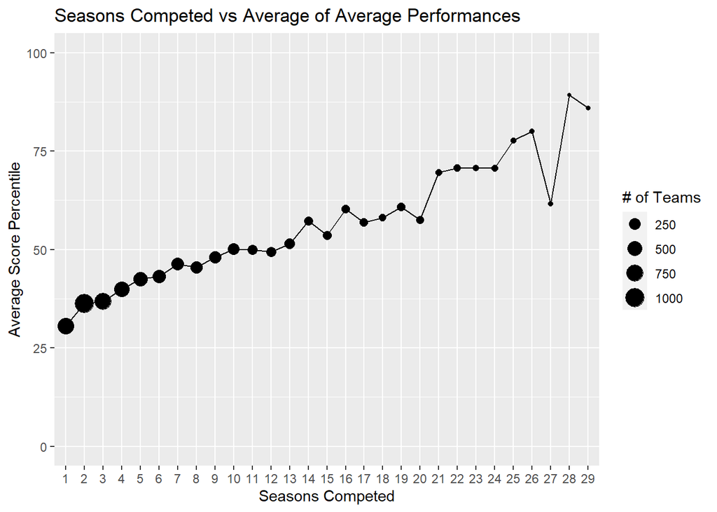

```r
team_percentile_avg %>%
  left_join(teams, by = c("team_num" = "team_number")) %>%
  filter(!is.na(years_competed)) %>%
  group_by(years_competed) %>%
  summarize(avg_avg_performance = mean(avg_performance), num_teams = n()) %>%
  ggplot() +
  geom_point(aes(as.factor(years_competed), avg_avg_performance, size = num_teams)) +
  geom_line(aes(as.factor(years_competed), avg_avg_performance, group = 1)) +
  ylim(0, 100) +
  labs(title = "Seasons Competed vs Average of Average Performances",
       x = "Seasons Competed",
       y = "Average Score Percentile",
       size = "# of Teams")
```

#### Number of Matches Played vs Average Performance

This chart shows how many matches each team has played across the years 2002 to 2019. As expected, teams with lower numbers have played more matches (because they’ve been around longer).

One team to notice is team 9999. This team does not actually exist. The number 9999 is used as a placeholder for a team that has not received a number yet. This usually only happens during preseason and offseason events, though it seems to have happened in a week 0 regional event in 2004.

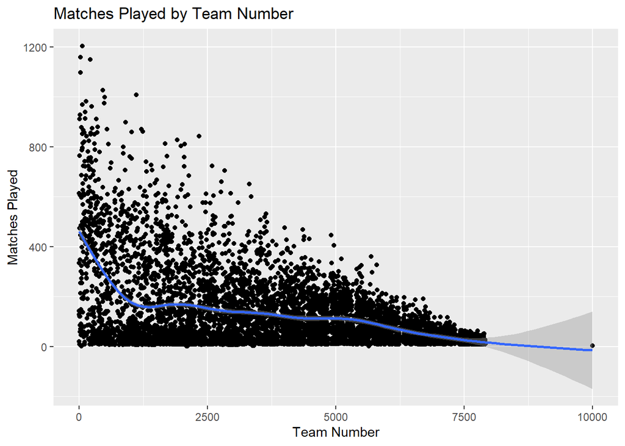

```r
matches_played_by_team <- matches_by_team %>%
  group_by(team_num) %>%
  summarize(played = n()) %>%
  ungroup()

matches_played_by_team %>%
  ggplot(aes(team_num, played)) +
  geom_point() +
  geom_smooth() +
  labs(title = "Matches Played by Team Number",
       x = "Team Number",
       y = "Matches Played")
```

We can look at the number of seasons competed vs number of matches played. Because teams can attend multiple events, plus some teams attend the championship, the number of matches played can vary greatly. Note that we only have match data going back to 2002, so teams that competed before that are missing matches in our data set.

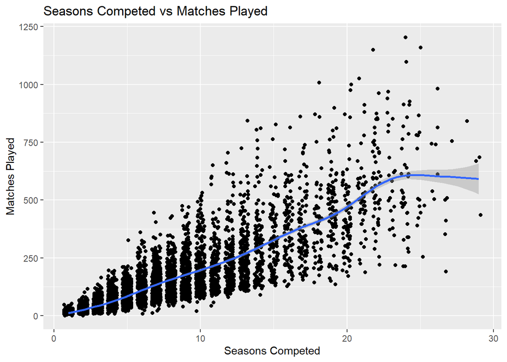

```r
matches_played_by_team %>%
  left_join(teams, by = c("team_num" = "team_number")) %>%
  ggplot(aes(years_competed, played)) +
  geom_jitter(height = 0, width = 0.3) +
  geom_smooth() +
  labs(title = "Seasons Competed vs Matches Played",
       x = "Seasons Competed",
       y = "Matches Played")
```

We can then compare the number of matches played by a team with their average performance.

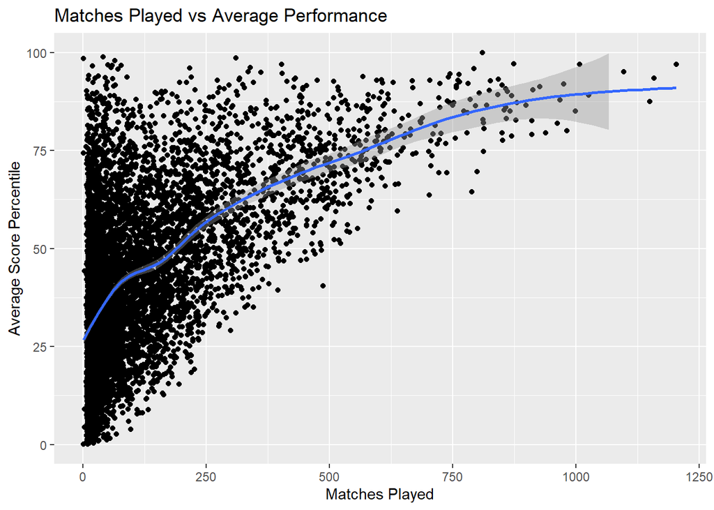

```r
team_percentile_avg %>%
  left_join(matches_played_by_team, by = "team_num") %>%
  ggplot(aes(played, avg_performance)) +
  geom_point() +
  geom_smooth() +
  ylim(0, 100) +
  labs(title = "Matches Played vs Average Performance",
       x = "Matches Played",
       y = "Average Score Percentile")
```

This time we see a very distinct improvement with more experience. This could be because of a few factors:

- More seasons mean better performance as well as more matches played
- Teams that attend the championship are usually there because they performed well in the regular season, meaning better performing teams get to play more matches

## Conclusion

It is tough to quantify the effect of experience on performance. The experienced teams both in terms of seasons completed and matches played are certainly much better on average and score higher. We also saw that the teams that progress the most through the course of the season are the ones that attend the most events. However, we can’t say this is all due to experience. Some of the top teams of all time as calculated by our performance metric lasted only one season and performed exceptionally well during that season. Success also brings more experience because teams that do well in an event and get to play in the playoff matches will get more experience. Teams that attend championship events in a season by performing well will also get to play more matches and thus get more experience. That said, we have found that a more experienced team tends to perform better in competition.

## Data Scraping

We got all of our match and team data from The Blue Alliance, a website that is dedicated to providing data and data analysis for the FIRST Robotics Competition. They have a public API that we were able to utilize to collect our data.

### Scraping Match Data

The match data on The Blue Alliance is split up by event. First we get a list of event names for a given year using the `/events/{year}` API endpoint. We then filter the events based on their type, omitting any offseason and preseason events. For each event, we use the `event/{event_name}/matches/simple` API endpoint to get our match data.

We then check that we actually got data (some events from the early years have no match data). If we did, we clean up our data. One part of cleaning the data includes extracting the 2-4 teams that competed on each alliance in each match. Each alliance’s teams are in a list in a column of the data frame. We would like to have the teams located in columns based on their position and alliance (i.e. `red_alliance_1`, `blue_alliance_3`, etc.). First, we use `unnest()` to create a new row for each team on the blue alliance. We then group the matches by their key, which is the unique identifier given by The Blue Alliance. Then, we assign a number to each row for a match by creating a new column with `seq_along()`. This is essentially creating a column with the index the team had in the list of teams. We then use `spread()` to put the team name in a column with the name `1`, `2`, `3`, or `4`, based on the value in that column we just created. Last, we either rename the column from `1` to `blue_alliance_1` if the column `1` exists, otherwise put `NA` into `blue_alliance_1`, and repeat this for `blue_alliance_2`, `blue_alliance_3` and `blue_alliance_4`. We then repeat these same steps for the red alliance. We also add the year, week, and type of the event to every row, as well as convert the `comp_level` column to a factor.

To combine all the events for a year into one data frame, we start with an empty data frame and use `bind_rows()` to populate it with each event. Then we recode the `event_type` column’s factor names from integers into strings that describe the event type. We also fill in the winning alliance for any matches without a winning alliance with `tie`, because if a match was a tie The Blue Alliance leaves that data point empty.

We then combine all the years into one comprehensive data frame, sort by `year`, `event_key`, `comp_level`, `set_number` and `match_number`.

Lastly, we save all this data to a `.rds` file. We use a `.rds` file because the 140,386 matches we have data for take up 2.6 MB to store when compressed into a `.rds` file, compared to 15.6 MB if uncompressed in a `.csv`.

After we read in the `.rds`, we do a little more data manipulation to denote postseason events separately from the regular season events in the `week` column using `case_when()`, followed by another `mutate()` that converts the week column to a factor. This is stored in the `matches` data frame.

We also create another data frame called `scores` which has each alliance score in its own row (meaning two rows per match). This is achieved with `pivot_longer()`, `mutate()`, and `recode_factor()`.

The last data frame we create when loading data contains the match data with each row having a single team from the match (meaning 4-8 rows per match). Starting with our `scores` data frame, we use `pivot_longer()` to create 8 rows per match, then filter out the rows that have no team (which shrinks the data frame from 2.25 million rows to only 1.65 million). Then we split up the column that contained the alliance and position the team had in the match into two columns containing those data points separately. We then remove any rows where the alliance the team was on doesn’t match up with the alliance whose score is stored in that row (which halves the size of our data frame to the final size of 826,282 rows). We then remove the `team_alliance` column (using the `!column_name` syntax for `select()` which requires a newer version of `dplyr` than is available on the R Server) because it contains the same data as the `alliance` column that already existed. Last, we create a new column with the team’s number as an integer by removing the `frc` prefix that The Blue Alliance includes in every team key.

### Scraping Team Data

The team data is available from the `teams/{page}` API endpoint. This returns a list of teams, which is split into pages of 500 teams at a time. We use `bind_rows()` again to combine these lists into one data frame.

The years that teams have competed in is not included in the data from above, so we have to get it separately for each team. The Blue Alliance has the `team/{team_key}/years_participated` endpoint for this. We created a function that is used by a `mutate()` to go through all the teams in our data frame and request a list of the years they participated. It then compiles a list of all the lists of years and returns that, which mutate puts into our data frame.

We then save this to another `.rds` file, this time because a `.csv` does not support having columns with a list data type.

When we read in the data, we create one last column which is the number of years the team has competed, based on the length of the list of years they have competed in. We also remove any teams that have a rookie year of 2020 because we have excluded all match data from 2020.

### Scraping Zip Code Data

To get the location of US zip codes, we are able to pull a table from a [GitHub Gist](https://gist.githubusercontent.com/erichurst/7882666/raw/5bdc46db47d9515269ab12ed6fb2850377fd869e/US%2520Zip%2520Codes%2520from%25202013%2520Government%2520Data) and save it as a `.csv`.